# End-of-Grade Score Stability Across Cohorts — EG DIB

## Overview

**Objective:** Assess whether end-of-grade ASER scores are stable across cohorts — that is, whether students who reach a given grade in different assessment years score similarly on average.

If scores at a given grade are similar across these cohorts, it supports the assumption that cohorts are comparable and that cross-cohort learning comparisons are valid. Systematic differences would suggest cohort-level heterogeneity or secular time trends in learning levels — either of which could confound cohort-based estimates.

**Scope:** All comparisons are restricted to the **control group** (`treatment == 0`, n = 3,396 students across 141 villages) to avoid any contamination from the Educate Girls program.

## Background: Cohort Assessment Schedule

The table below reproduces the cohort structure from the study documentation. Asterisks indicate that a cohort was **not assessed** in that round.

| Cohort label | Grade at Baseline | Grade at Y1 Endline | Grade at Y2 Endline | Grade at Y3 Endline | Years exposed to EG |
| --- | --- | --- | --- | --- | --- |
| Grade 1_Y1 | 1 | 1* | 2* | 3 | 1 |
| Grade 2_Y1 | 2 | 2* | 3 | 4 | 2 |
| Grade 3_Y1 | 3 | 3 | 4 | 5 | 3 |
| Grade 4_Y1 | 4 | 4 | 5 | 6* | 2 |
| Grade 5_Y1 | 5 | 5 | 6* | 7* | 1 |

Assessment dates: Baseline = September 2015; Y1 Endline = February 2016; Y2 Endline = February 2017; Y3 Endline = February 2018.

### Comparable cohort–round combinations

Reading across each row, the same end-of-grade score can be observed from the following cohort–round combinations:

| End of grade | Cohort | Assessment round | Variable suffix |
| --- | --- | --- | --- |
| 3 | Grade 1_Y1 | Y3 Endline | `_ely3` |
| 3 | Grade 2_Y1 | Y2 Endline | `_ely2` |
| 3 | Grade 3_Y1 | Y1 Endline | `_ely1` |
| 3 | Grade 4_Y1 | Baseline | `_bl` |
| 4 | Grade 2_Y1 | Y3 Endline | `_ely3` |
| 4 | Grade 3_Y1 | Y2 Endline | `_ely2` |
| 4 | Grade 4_Y1 | Y1 Endline | `_ely1` |
| 4 | Grade 5_Y1 | Baseline | `_bl` |
| 5 | Grade 3_Y1 | Y3 Endline | `_ely3` |
| 5 | Grade 4_Y1 | Y2 Endline | `_ely2` |
| 5 | Grade 5_Y1 | Y1 Endline | `_ely1` |

## Analysis

For each end-of-grade comparison, we compute mean scores by cohort and plot them across subjects. Comparisons are restricted to the control group.

Subjects covered: Hindi (6-point scale), Math (5-point scale), English (5-point scale), and Total (16-point composite).

```r
library(haven)
library(dplyr)
library(tidyr)
library(ggplot2)
library(survey)
library(gt)

df <- read_dta("../data/raw/EG DIB_Main Student Data.dta")
ctrl <- filter(df, treatment == 0)
```

```r
subject_levels <- c("hindi", "math", "english", "total")
subject_labels <- c("Hindi", "Math", "English", "Total")

grade3 <- bind_rows(
  ctrl |>
    filter(child_class_bl == 1, assessed_ely3 == 1) |>
    transmute(cohort = "Grade 1_Y1 (ely3)", village_id_rand,
              hindi = hindi_ely3, math = math_ely3,
              english = english_ely3, total = total_ely3),
  ctrl |>
    filter(child_class_bl == 2, assessed_ely2 == 1) |>
    transmute(cohort = "Grade 2_Y1 (ely2)", village_id_rand,
              hindi = hindi_ely2, math = math_ely2,
              english = english_ely2, total = total_ely2),
  ctrl |>
    filter(child_class_bl == 3, assessed_ely1 == 1) |>
    transmute(cohort = "Grade 3_Y1 (ely1)", village_id_rand,
              hindi = hindi_ely1, math = math_ely1,
              english = english_ely1, total = total_ely1),
  ctrl |>
    filter(child_class_bl == 4, assessed_bl == 1) |>
    transmute(cohort = "Grade 4_Y1 (bl)", village_id_rand,
              hindi = hindi_bl, math = math_bl,
              english = english_bl, total = total_bl)
) |>
  mutate(cohort = factor(cohort,
    levels = c("Grade 1_Y1 (ely3)", "Grade 2_Y1 (ely2)", "Grade 3_Y1 (ely1)", "Grade 4_Y1 (bl)")))

grade4 <- bind_rows(
  ctrl |>
    filter(child_class_bl == 2, assessed_ely3 == 1) |>
    transmute(cohort = "Grade 2_Y1 (ely3)", village_id_rand,
              hindi = hindi_ely3, math = math_ely3,
              english = english_ely3, total = total_ely3),
  ctrl |>
    filter(child_class_bl == 3, assessed_ely2 == 1) |>
    transmute(cohort = "Grade 3_Y1 (ely2)", village_id_rand,
              hindi = hindi_ely2, math = math_ely2,
              english = english_ely2, total = total_ely2),
  ctrl |>
    filter(child_class_bl == 4, assessed_ely1 == 1) |>
    transmute(cohort = "Grade 4_Y1 (ely1)", village_id_rand,
              hindi = hindi_ely1, math = math_ely1,
              english = english_ely1, total = total_ely1),
  ctrl |>
    filter(child_class_bl == 5, assessed_bl == 1) |>
    transmute(cohort = "Grade 5_Y1 (bl)", village_id_rand,
              hindi = hindi_bl, math = math_bl,
              english = english_bl, total = total_bl)
) |>
  mutate(cohort = factor(cohort,
    levels = c("Grade 2_Y1 (ely3)", "Grade 3_Y1 (ely2)", "Grade 4_Y1 (ely1)", "Grade 5_Y1 (bl)")))

grade5 <- bind_rows(
  ctrl |>
    filter(child_class_bl == 3, assessed_ely3 == 1) |>
    transmute(cohort = "Grade 3_Y1 (ely3)", village_id_rand,
              hindi = hindi_ely3, math = math_ely3,
              english = english_ely3, total = total_ely3),
  ctrl |>
    filter(child_class_bl == 4, assessed_ely2 == 1) |>
    transmute(cohort = "Grade 4_Y1 (ely2)", village_id_rand,
              hindi = hindi_ely2, math = math_ely2,
              english = english_ely2, total = total_ely2),
  ctrl |>
    filter(child_class_bl == 5, assessed_ely1 == 1) |>
    transmute(cohort = "Grade 5_Y1 (ely1)", village_id_rand,
              hindi = hindi_ely1, math = math_ely1,
              english = english_ely1, total = total_ely1)
) |>
  mutate(cohort = factor(cohort,
    levels = c("Grade 3_Y1 (ely3)", "Grade 4_Y1 (ely2)", "Grade 5_Y1 (ely1)")))

cohort_means <- function(data, grade_label) {
  data |>
    pivot_longer(all_of(subject_levels), names_to = "subject", values_to = "score") |>
    group_by(cohort, subject) |>
    group_modify(~ {
      des <- svydesign(ids = ~village_id_rand, data = .x)
      est <- svymean(~score, des, na.rm = TRUE)
      tibble(mean_score = as.numeric(est), se = as.numeric(SE(est)))
    }) |>
    ungroup() |>
    mutate(
      subject = factor(subject, levels = subject_levels, labels = subject_labels),
      grade   = grade_label
    )
}

# Returns a formatted string of SD (across cohort means) for each subject
sd_across_cohorts <- function(means_data) {
  means_data |>
    group_by(subject) |>
    summarise(sd = sd(mean_score, na.rm = TRUE), .groups = "drop") |>
    mutate(label = paste0(subject, ": ", round(sd, 2))) |>
    pull(label) |>
    paste(collapse = "; ")
}

# Compute cohort means after dividing each student's score by the pooled SD
# for that grade-subject combination (SD computed across all cohorts in `data`)
cohort_means_normalized <- function(data, grade_label) {
  long <- data |>
    pivot_longer(all_of(subject_levels), names_to = "subject", values_to = "score")

  sds <- long |>
    group_by(subject) |>
    summarise(sd = sd(score, na.rm = TRUE), .groups = "drop")

  long |>
    left_join(sds, by = "subject") |>
    mutate(score = score / sd) |>
    group_by(cohort, subject) |>
    group_modify(~ {
      des <- svydesign(ids = ~village_id_rand, data = .x)
      est <- svymean(~score, des, na.rm = TRUE)
      tibble(mean_score = as.numeric(est), se = as.numeric(SE(est)))
    }) |>
    ungroup() |>
    mutate(
      subject = factor(subject, levels = subject_levels, labels = subject_labels),
      grade   = grade_label
    )
}

means3 <- cohort_means(grade3, "End of Grade 3")
means4 <- cohort_means(grade4, "End of Grade 4")
means5 <- cohort_means(grade5, "End of Grade 5")

means3_norm <- cohort_means_normalized(grade3, "End of Grade 3")
means4_norm <- cohort_means_normalized(grade4, "End of Grade 4")
means5_norm <- cohort_means_normalized(grade5, "End of Grade 5")

make_gt_table <- function(data, y_label = "Mean score (SE)") {
  data |>
    mutate(cell = paste0(round(mean_score, 2), " (", round(se, 2), ")")) |>
    select(cohort, subject, cell) |>
    pivot_wider(names_from = subject, values_from = cell) |>
    gt() |>
    cols_label(cohort = "Cohort") |>
    tab_spanner(label = y_label, columns = -cohort) |>
    tab_options(table.width = pct(100))
}
```

### End of Grade 3

```r
n3 <- grade3 |> count(cohort) |> mutate(label = paste0(cohort, ": n = ", n))
sd3 <- sd_across_cohorts(means3)
```

Sample sizes (control group, assessed at relevant round): Grade 1_Y1 (ely3): n = 514; Grade 2_Y1 (ely2): n = 629; Grade 3_Y1 (ely1): n = 668; Grade 4_Y1 (bl): n = 679. SD of cohort means by subject: Hindi: 0.17; Math: 0.08; English: 0.08; Total: 0.29.

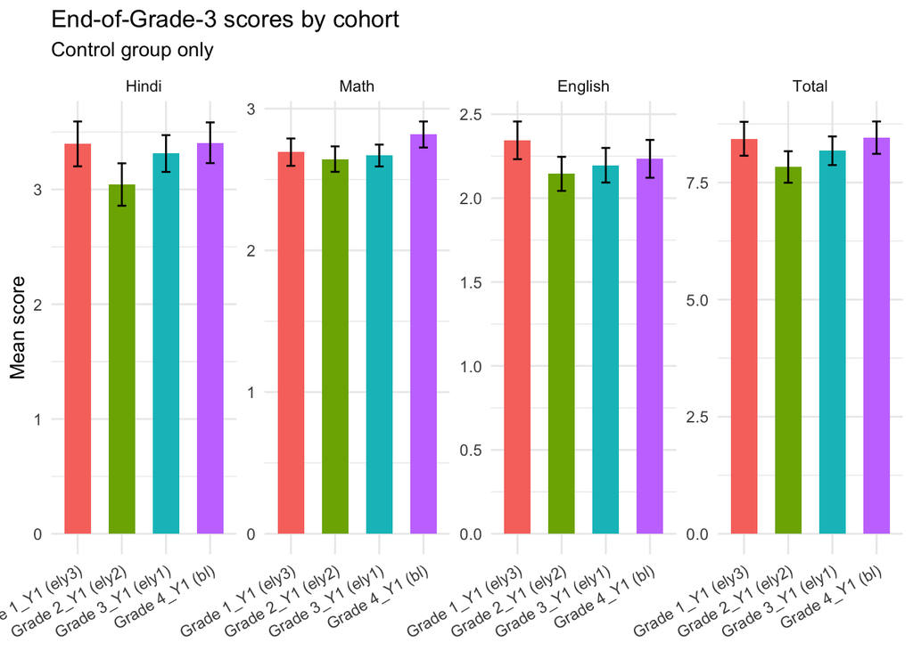

```r
ggplot(means3, aes(x = cohort, y = mean_score, fill = cohort)) +
  geom_col(width = 0.6) +
  geom_errorbar(aes(ymin = mean_score - 1.96 * se, ymax = mean_score + 1.96 * se), width = 0.2) +
  facet_wrap(~ subject, scales = "free_y", nrow = 1) +
  labs(
    title = "End-of-Grade-3 scores by cohort",
    subtitle = "Control group only",
    x = NULL,
    y = "Mean score"
  ) +
  theme_minimal() +
  theme(
    legend.position = "none",
    axis.text.x = element_text(angle = 30, hjust = 1)
  )
```

```r
make_gt_table(means3)
```

| Cohort | Mean score (SE) English | Mean score (SE) Hindi | Mean score (SE) Math | Mean score (SE) Total |
| --- | --- | --- | --- | --- |
| Grade 1_Y1 (ely3) | 2.34 (0.06) | 3.4 (0.1) | 2.69 (0.05) | 8.43 (0.18) |
| Grade 2_Y1 (ely2) | 2.14 (0.05) | 3.04 (0.09) | 2.64 (0.05) | 7.83 (0.17) |
| Grade 3_Y1 (ely1) | 2.2 (0.05) | 3.31 (0.08) | 2.67 (0.04) | 8.18 (0.16) |
| Grade 4_Y1 (bl) | 2.23 (0.06) | 3.41 (0.09) | 2.82 (0.05) | 8.46 (0.18) |

Scores divided by the pooled SD for each grade–subject combination, so bars are in units of SD and comparable across subjects.

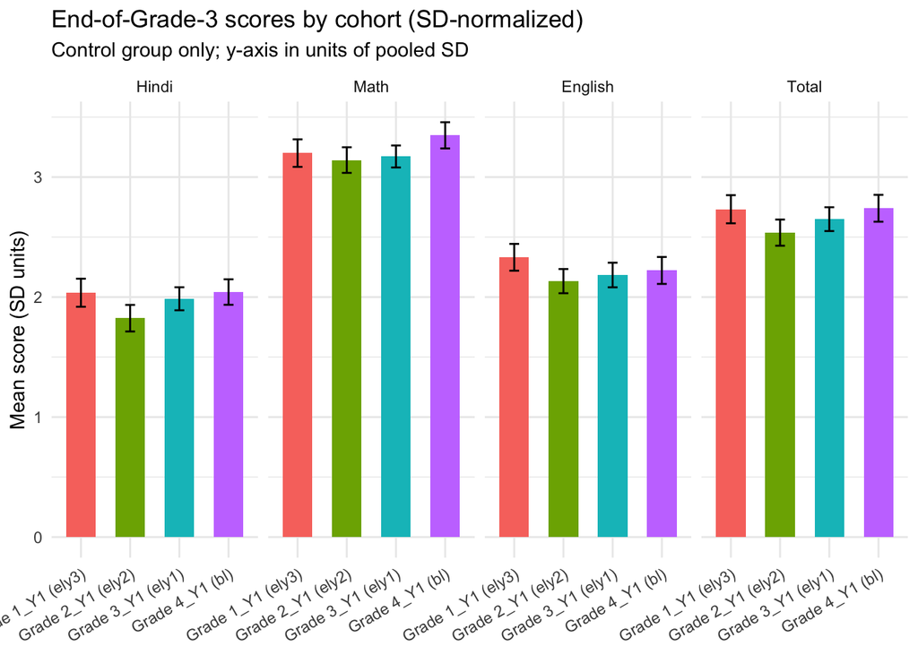

```r
ggplot(means3_norm, aes(x = cohort, y = mean_score, fill = cohort)) +
  geom_col(width = 0.6) +
  geom_errorbar(aes(ymin = mean_score - 1.96 * se, ymax = mean_score + 1.96 * se), width = 0.2) +
  facet_wrap(~ subject, nrow = 1) +
  labs(
    title = "End-of-Grade-3 scores by cohort (SD-normalized)",
    subtitle = "Control group only; y-axis in units of pooled SD",
    x = NULL,
    y = "Mean score (SD units)"
  ) +
  theme_minimal() +
  theme(
    legend.position = "none",
    axis.text.x = element_text(angle = 30, hjust = 1)
  )
```

```r
make_gt_table(means3_norm, "Mean score in SD units (SE)")
```

| Cohort | Mean score in SD units (SE) English | Mean score in SD units (SE) Hindi | Mean score in SD units (SE) Math | Mean score in SD units (SE) Total |
| --- | --- | --- | --- | --- |
| Grade 1_Y1 (ely3) | 2.33 (0.06) | 2.04 (0.06) | 3.2 (0.06) | 2.73 (0.06) |
| Grade 2_Y1 (ely2) | 2.13 (0.05) | 1.82 (0.06) | 3.14 (0.05) | 2.54 (0.06) |
| Grade 3_Y1 (ely1) | 2.18 (0.05) | 1.99 (0.05) | 3.17 (0.05) | 2.65 (0.05) |
| Grade 4_Y1 (bl) | 2.22 (0.06) | 2.04 (0.05) | 3.35 (0.06) | 2.74 (0.06) |

### End of Grade 4

```r
n4 <- grade4 |> count(cohort) |> mutate(label = paste0(cohort, ": n = ", n))
sd4 <- sd_across_cohorts(means4)
```

Sample sizes: Grade 2_Y1 (ely3): n = 619; Grade 3_Y1 (ely2): n = 643; Grade 4_Y1 (ely1): n = 665; Grade 5_Y1 (bl): n = 684. SD of cohort means by subject: Hindi: 0.06; Math: 0.1; English: 0.08; Total: 0.21.

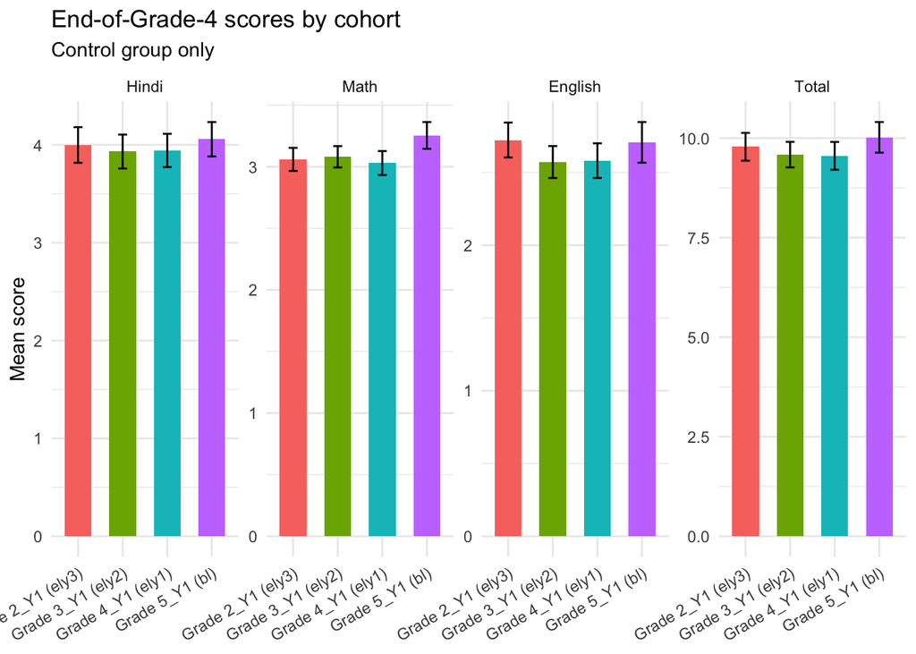

```r
ggplot(means4, aes(x = cohort, y = mean_score, fill = cohort)) +
  geom_col(width = 0.6) +
  geom_errorbar(aes(ymin = mean_score - 1.96 * se, ymax = mean_score + 1.96 * se), width = 0.2) +
  facet_wrap(~ subject, scales = "free_y", nrow = 1) +
  labs(
    title = "End-of-Grade-4 scores by cohort",
    subtitle = "Control group only",
    x = NULL,
    y = "Mean score"
  ) +
  theme_minimal() +
  theme(
    legend.position = "none",
    axis.text.x = element_text(angle = 30, hjust = 1)
  )
```

```r
make_gt_table(means4)
```

| Cohort | Mean score (SE) English | Mean score (SE) Hindi | Mean score (SE) Math | Mean score (SE) Total |
| --- | --- | --- | --- | --- |
| Grade 2_Y1 (ely3) | 2.72 (0.06) | 4 (0.09) | 3.06 (0.05) | 9.78 (0.18) |
| Grade 3_Y1 (ely2) | 2.57 (0.06) | 3.93 (0.09) | 3.08 (0.04) | 9.58 (0.16) |
| Grade 4_Y1 (ely1) | 2.58 (0.06) | 3.94 (0.09) | 3.03 (0.05) | 9.55 (0.18) |
| Grade 5_Y1 (bl) | 2.71 (0.07) | 4.06 (0.09) | 3.25 (0.06) | 10.02 (0.2) |

Scores divided by the pooled SD for each grade–subject combination, so bars are in units of SD and comparable across subjects.

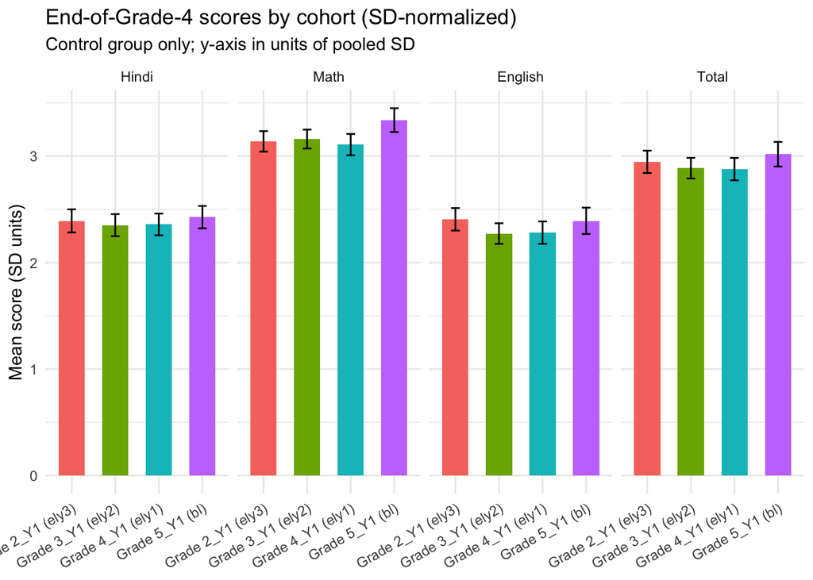

```r
ggplot(means4_norm, aes(x = cohort, y = mean_score, fill = cohort)) +
  geom_col(width = 0.6) +
  geom_errorbar(aes(ymin = mean_score - 1.96 * se, ymax = mean_score + 1.96 * se), width = 0.2) +
  facet_wrap(~ subject, nrow = 1) +
  labs(
    title = "End-of-Grade-4 scores by cohort (SD-normalized)",
    subtitle = "Control group only; y-axis in units of pooled SD",
    x = NULL,
    y = "Mean score (SD units)"
  ) +
  theme_minimal() +
  theme(
    legend.position = "none",
    axis.text.x = element_text(angle = 30, hjust = 1)
  )
```

```r
make_gt_table(means4_norm, "Mean score in SD units (SE)")
```

| Cohort | Mean score in SD units (SE) English | Mean score in SD units (SE) Hindi | Mean score in SD units (SE) Math | Mean score in SD units (SE) Total |
| --- | --- | --- | --- | --- |
| Grade 2_Y1 (ely3) | 2.41 (0.05) | 2.39 (0.06) | 3.14 (0.05) | 2.95 (0.05) |
| Grade 3_Y1 (ely2) | 2.27 (0.05) | 2.35 (0.05) | 3.16 (0.05) | 2.89 (0.05) |
| Grade 4_Y1 (ely1) | 2.28 (0.05) | 2.36 (0.05) | 3.11 (0.05) | 2.88 (0.05) |
| Grade 5_Y1 (bl) | 2.39 (0.06) | 2.43 (0.05) | 3.34 (0.06) | 3.02 (0.06) |

### End of Grade 5

```r
n5 <- grade5 |> count(cohort) |> mutate(label = paste0(cohort, ": n = ", n))
sd5 <- sd_across_cohorts(means5)
```

Sample sizes: Grade 3_Y1 (ely3): n = 634; Grade 4_Y1 (ely2): n = 654; Grade 5_Y1 (ely1): n = 672. SD of cohort means by subject: Hindi: 0.15; Math: 0.04; English: 0.1; Total: 0.29.

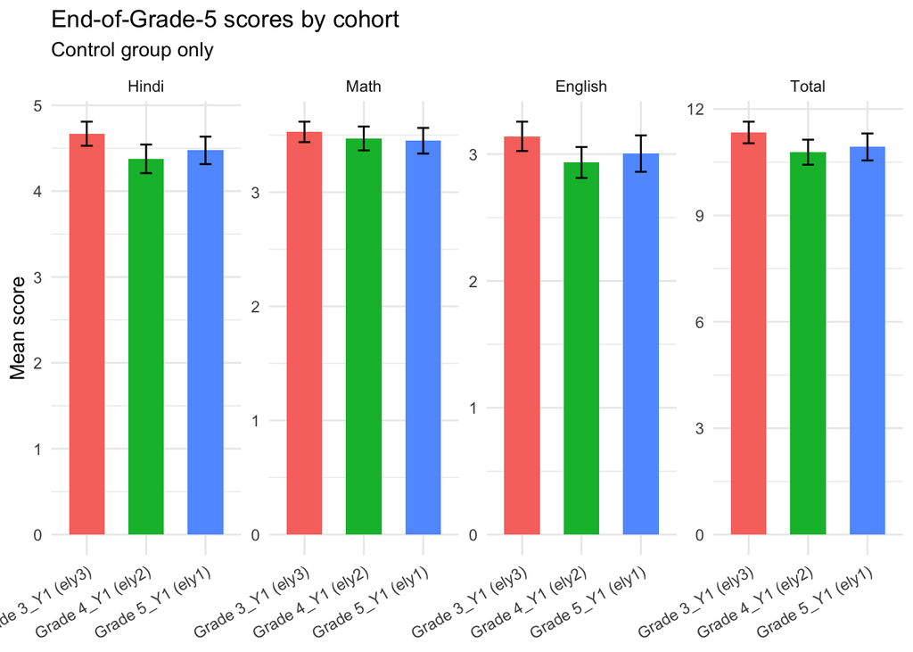

```r
ggplot(means5, aes(x = cohort, y = mean_score, fill = cohort)) +
  geom_col(width = 0.6) +
  geom_errorbar(aes(ymin = mean_score - 1.96 * se, ymax = mean_score + 1.96 * se), width = 0.2) +
  facet_wrap(~ subject, scales = "free_y", nrow = 1) +
  labs(
    title = "End-of-Grade-5 scores by cohort",
    subtitle = "Control group only",
    x = NULL,
    y = "Mean score"
  ) +
  theme_minimal() +
  theme(
    legend.position = "none",
    axis.text.x = element_text(angle = 30, hjust = 1)
  )
```

```r
make_gt_table(means5)
```

| Cohort | Mean score (SE) English | Mean score (SE) Hindi | Mean score (SE) Math | Mean score (SE) Total |
| --- | --- | --- | --- | --- |
| Grade 3_Y1 (ely3) | 3.14 (0.06) | 4.67 (0.07) | 3.53 (0.05) | 11.34 (0.16) |
| Grade 4_Y1 (ely2) | 2.93 (0.06) | 4.38 (0.08) | 3.47 (0.05) | 10.78 (0.18) |
| Grade 5_Y1 (ely1) | 3 (0.07) | 4.47 (0.08) | 3.45 (0.06) | 10.93 (0.19) |

Scores divided by the pooled SD for each grade–subject combination, so bars are in units of SD and comparable across subjects.

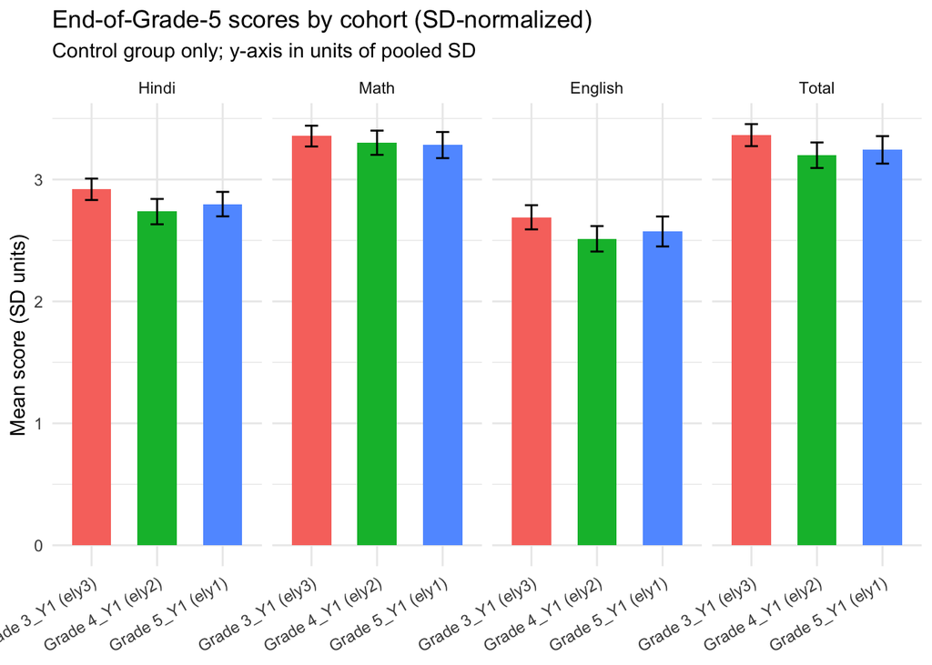

```r
ggplot(means5_norm, aes(x = cohort, y = mean_score, fill = cohort)) +
  geom_col(width = 0.6) +
  geom_errorbar(aes(ymin = mean_score - 1.96 * se, ymax = mean_score + 1.96 * se), width = 0.2) +
  facet_wrap(~ subject, nrow = 1) +
  labs(
    title = "End-of-Grade-5 scores by cohort (SD-normalized)",
    subtitle = "Control group only; y-axis in units of pooled SD",
    x = NULL,
    y = "Mean score (SD units)"
  ) +
  theme_minimal() +
  theme(
    legend.position = "none",
    axis.text.x = element_text(angle = 30, hjust = 1)
  )
```

```r
make_gt_table(means5_norm, "Mean score in SD units (SE)")
```

| Cohort | Mean score in SD units (SE) English | Mean score in SD units (SE) Hindi | Mean score in SD units (SE) Math | Mean score in SD units (SE) Total |
| --- | --- | --- | --- | --- |
| Grade 3_Y1 (ely3) | 2.69 (0.05) | 2.92 (0.04) | 3.36 (0.04) | 3.36 (0.05) |
| Grade 4_Y1 (ely2) | 2.51 (0.05) | 2.74 (0.05) | 3.3 (0.05) | 3.2 (0.05) |
| Grade 5_Y1 (ely1) | 2.57 (0.06) | 2.8 (0.05) | 3.28 (0.05) | 3.24 (0.06) |

*Note: ASER scales — Hindi: 1 (Beginner) to 6 (Story Plus); Math: 1 (Beginner) to 5 (Division); English: 1 (Beginner) to 5 (Sentence); Total: sum of the three scales, range 3–16.*

## Learning Gains Within a Single Year

The code above compares end of grade learning *levels* for several cohorts. In two cases, we can also compare learning *gains* over a year across cohorts:

For each comparison, gains are computed at the individual level (later score minus earlier score) and then averaged with cluster-robust standard errors at the village level. Comparisons are restricted to the control group and to students assessed at both relevant rounds.

```r
gains_3to4 <- bind_rows(
  ctrl |>
    filter(child_class_bl == 2, assessed_ely2 == 1, assessed_ely3 == 1) |>
    transmute(cohort = "Grade 2_Y1", village_id_rand,
              hindi   = hindi_ely3   - hindi_ely2,
              math    = math_ely3    - math_ely2,
              english = english_ely3 - english_ely2,
              total   = total_ely3   - total_ely2),
  ctrl |>
    filter(child_class_bl == 3, assessed_ely1 == 1, assessed_ely2 == 1) |>
    transmute(cohort = "Grade 3_Y1", village_id_rand,
              hindi   = hindi_ely2   - hindi_ely1,
              math    = math_ely2    - math_ely1,
              english = english_ely2 - english_ely1,
              total   = total_ely2   - total_ely1)
) |>
  mutate(cohort = factor(cohort, levels = c("Grade 2_Y1", "Grade 3_Y1")))

gains_4to5 <- bind_rows(
  ctrl |>
    filter(child_class_bl == 3, assessed_ely2 == 1, assessed_ely3 == 1) |>
    transmute(cohort = "Grade 3_Y1", village_id_rand,
              hindi   = hindi_ely3   - hindi_ely2,
              math    = math_ely3    - math_ely2,
              english = english_ely3 - english_ely2,
              total   = total_ely3   - total_ely2),
  ctrl |>
    filter(child_class_bl == 4, assessed_ely1 == 1, assessed_ely2 == 1) |>
    transmute(cohort = "Grade 4_Y1", village_id_rand,
              hindi   = hindi_ely2   - hindi_ely1,
              math    = math_ely2    - math_ely1,
              english = english_ely2 - english_ely1,
              total   = total_ely2   - total_ely1)
) |>
  mutate(cohort = factor(cohort, levels = c("Grade 3_Y1", "Grade 4_Y1")))

gains_means_3to4 <- cohort_means(gains_3to4, "Grade 3 → Grade 4")
gains_means_4to5 <- cohort_means(gains_4to5, "Grade 4 → Grade 5")
```

### Grade 3 to Grade 4

```r
ng34 <- gains_3to4 |> count(cohort) |> mutate(label = paste0(cohort, ": n = ", n))
sdg34 <- sd_across_cohorts(gains_means_3to4)
```

Sample sizes (control group, assessed at both relevant rounds): Grade 2_Y1: n = 610; Grade 3_Y1: n = 636. SD of cohort mean gains by subject: Hindi: 0.22; Math: 0; English: 0.15; Total: 0.37.

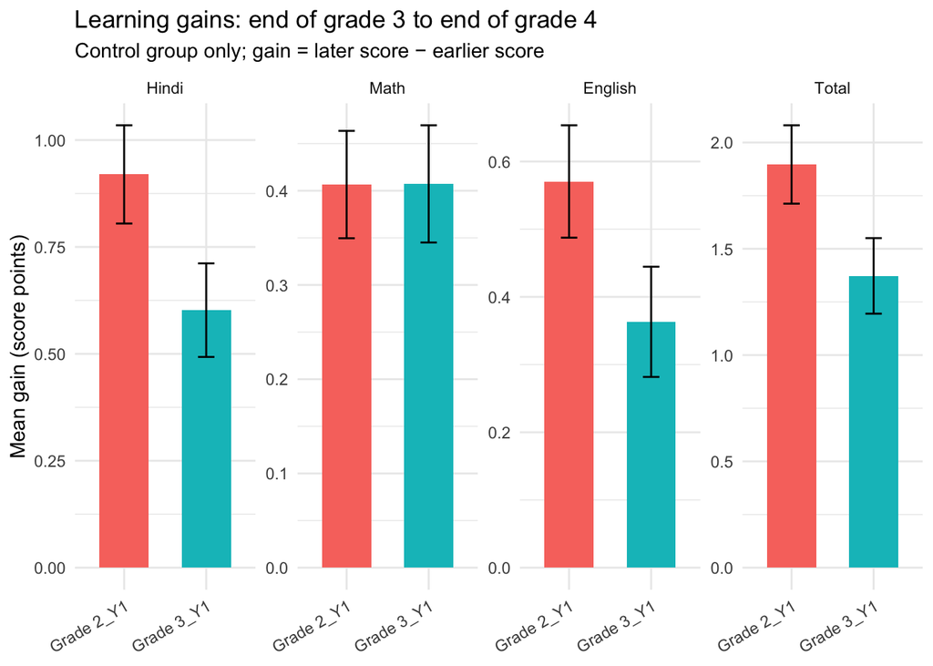

```r
ggplot(gains_means_3to4, aes(x = cohort, y = mean_score, fill = cohort)) +
  geom_col(width = 0.6) +
  geom_errorbar(aes(ymin = mean_score - 1.96 * se, ymax = mean_score + 1.96 * se), width = 0.2) +
  facet_wrap(~ subject, scales = "free_y", nrow = 1) +
  labs(
    title = "Learning gains: end of grade 3 to end of grade 4",
    subtitle = "Control group only; gain = later score − earlier score",
    x = NULL,
    y = "Mean gain (score points)"
  ) +
  theme_minimal() +
  theme(
    legend.position = "none",
    axis.text.x = element_text(angle = 30, hjust = 1)
  )
```

```r
make_gt_table(gains_means_3to4, "Mean gain in score points (SE)")
```

| Cohort | Mean gain in score points (SE) English | Mean gain in score points (SE) Hindi | Mean gain in score points (SE) Math | Mean gain in score points (SE) Total |
| --- | --- | --- | --- | --- |
| Grade 2_Y1 | 0.57 (0.04) | 0.92 (0.06) | 0.41 (0.03) | 1.9 (0.09) |
| Grade 3_Y1 | 0.36 (0.04) | 0.6 (0.06) | 0.41 (0.03) | 1.37 (0.09) |

### Grade 4 to Grade 5

```r
ng45 <- gains_4to5 |> count(cohort) |> mutate(label = paste0(cohort, ": n = ", n))
sdg45 <- sd_across_cohorts(gains_means_4to5)
```

Sample sizes (control group, assessed at both relevant rounds): Grade 3_Y1: n = 623; Grade 4_Y1: n = 650. SD of cohort mean gains by subject: Hindi: 0.2; Math: 0; English: 0.14; Total: 0.34.

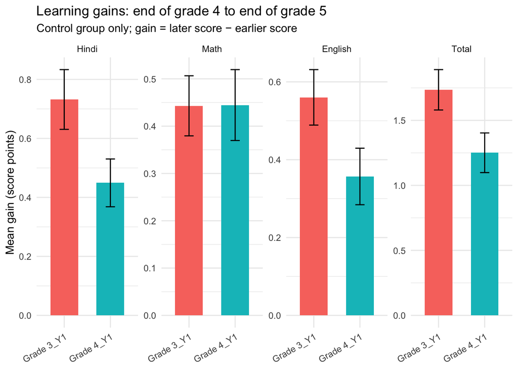

```r
ggplot(gains_means_4to5, aes(x = cohort, y = mean_score, fill = cohort)) +
  geom_col(width = 0.6) +
  geom_errorbar(aes(ymin = mean_score - 1.96 * se, ymax = mean_score + 1.96 * se), width = 0.2) +
  facet_wrap(~ subject, scales = "free_y", nrow = 1) +
  labs(
    title = "Learning gains: end of grade 4 to end of grade 5",
    subtitle = "Control group only; gain = later score − earlier score",
    x = NULL,
    y = "Mean gain (score points)"
  ) +
  theme_minimal() +
  theme(
    legend.position = "none",
    axis.text.x = element_text(angle = 30, hjust = 1)
  )
```

```r
make_gt_table(gains_means_4to5, "Mean gain in score points (SE)")
```

| Cohort | Mean gain in score points (SE) English | Mean gain in score points (SE) Hindi | Mean gain in score points (SE) Math | Mean gain in score points (SE) Total |
| --- | --- | --- | --- | --- |
| Grade 3_Y1 | 0.56 (0.04) | 0.73 (0.05) | 0.44 (0.03) | 1.74 (0.08) |
| Grade 4_Y1 | 0.36 (0.04) | 0.45 (0.04) | 0.44 (0.04) | 1.25 (0.08) |

*Note: ASER scales — Hindi: 1 (Beginner) to 6 (Story Plus); Math: 1 (Beginner) to 5 (Division); English: 1 (Beginner) to 5 (Sentence); Total: sum of the three scales, range 3–16.*